# Parte 3: Recomendación

# Modelo base

Si $x_{ij}$ es el gusto del usuario $i$ por la película $j$, entonces nuestra predicción es $\hat{x}_{uj} = \hat{b}_j + (\hat{a}_i-\hat{\mu} )$

donde $a_i$ indica un nivel general de calificaciones del usuario $i$, y $b_j$ es el nivel general de gusto por la película. Usualmente ponemos:

1. Media general $\hat{\mu} =\frac{1}{T}\sum_{s,t} x_{st}$
2. Promedio de calificaciones de usuario $i$ $\hat{a}_i =\frac{1}{M_i}\sum_{t} x_{i,t}$
3. Promedio de calificaciones de la película $j$ $\hat{b}_j =\frac{1}{N_j}\sum_{s} x_{s,j}$

También podemos escribir, en términos de desviaciones:

$\hat{x}_{ij} = \hat{\mu} + \hat{c}_i + \hat{d}_j$ donde

. Media general $\hat{\mu} =\frac{1}{T}\sum_{s,t} x_{st}$ 2. Desviación de las calificaciones de usuario $i$ respecto a la media general $\hat{c}_i =\frac{1}{M_i}\sum_{t} x_{it} - \hat{\mu}$ 3. Desviación de la película $j$ respecto a la media general $\hat{b_j} =\frac{1}{N_j}\sum_{s} x_{sj}- \hat{\mu}$

Una vez que observamos una calificación $x_{ij}$, el residual del modelo de referencia es $r_{ij} = x_{ij} - \hat{x_{ij}}$

```r
medias.usuario.e <- dat.entrena %>% group_by(user_id) %>% dplyr::summarise(media_usu = mean(rating), num_calif_usu = length(rating))
medias.peliculas.e <- dat.entrena %>% group_by(movie_id) %>% summarise(media_peli = mean(rating), num_calif_peli = length(rating))
media.gral.e <- mean(dat.entrena$rating)
dat.valida.2 <- dat.valida %>%
  left_join(medias.usuario.e) %>%
  left_join(medias.peliculas.e) %>%
  mutate(media.gral = media.gral.e) %>%
  mutate(prediccion = media_usu - media.gral + media_peli)
# sin prediccion, inputamos con la media general
dat.valida.2$prediccion[is.na(dat.valida.2$prediccion)] <- media.gral.e

sqrt(mean((dat.valida.2$prediccion - dat.valida.2$rating)^2))
```

```
## [1] 0.9271
```

Revisemos un poco mas el error de validacion. Veamos cual es el efecto de las peliculas que tienen pocas calificaciones. Se ve que tenemos la dificultad del ruido para centrar las calificaciones de usuarios o películas cuando hay pocas calificaciones.

```r
medias.peliculas <- dat.2 %>% group_by(movie_id) %>% summarise(media_peli = mean(rating), num_calif_peli = length(rating))
media.gral <- mean(dat.2$rating)
medias.p.2 <- left_join(medias.peliculas, movies.df)
arrange(medias.p.2, desc(media_peli)) %>% head
```

```
## Source: local data frame [6 x 5]
##
##   movie_id media_peli num_calif_peli
## 1      787          5              3
## 2      989          5              1
## 3     1830          5              1
## 4     3172          5              1
## 5     3233          5              2
## 6     3280          5              1
## Variables not shown: movie_nom (chr), tipo (chr)
```

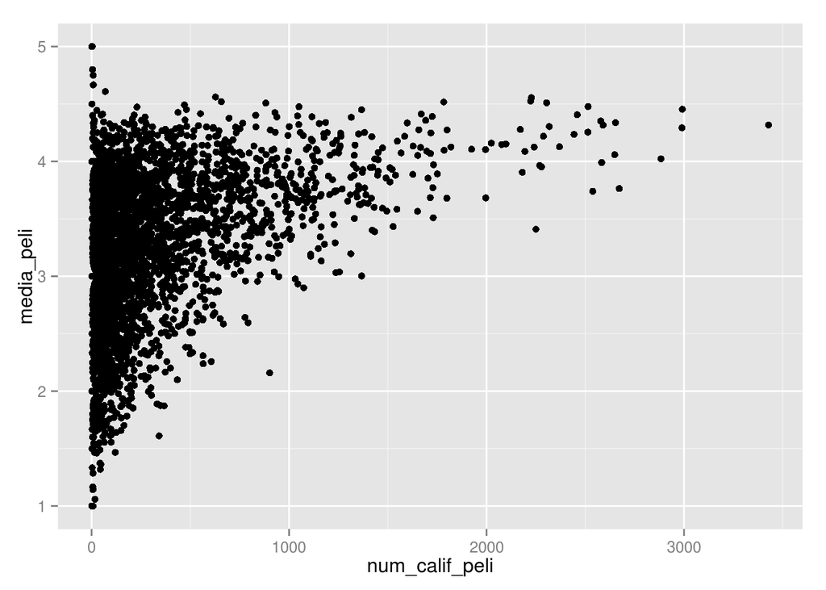

```r
ggplot(medias.p.2, aes(x=num_calif_peli, y=media_peli)) + geom_point()
```

Podemos regularizar tomando

$\hat{x_{ij}} = \hat{\mu} + \frac{n_i}{\lambda+n_i} \hat{a_i} + \frac{m_j}{\lambda+m_j}\hat{b_j}$

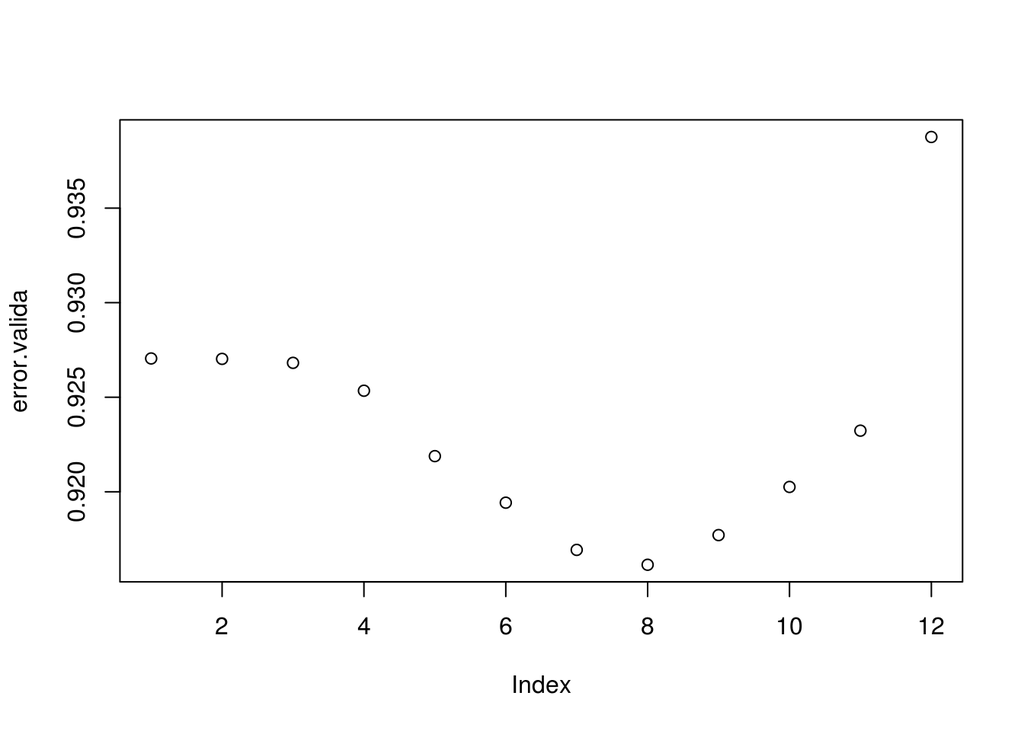

```r
error.valida <- sapply(c(0.001,0.01,0.1,1,5,10,20,40,60,80,100,200),
                function(lambda){

                  dat.valida.2 <- dat.valida %>%
                    left_join(medias.usuario.e, by='user_id') %>%
                    left_join(medias.peliculas.e, by='movie_id') %>%
                    mutate(media.gral = media.gral.e) %>%
                    mutate(prediccion = media.gral + (num_calif_usu/(num_calif_usu+lambda))*(media_usu - media.gral) +
             (num_calif_peli/(num_calif_peli+lambda))*(media_peli-media.gral))
                 dat.valida.2$prediccion[is.na(dat.valida.2$prediccion)] <- media.gral.e

                 sqrt(mean((dat.valida.2$prediccion - dat.valida.2$rating)^2))
})

plot(error.valida)
```

El minimio del error de validacion se obtiene en 0.9161. Sin embargo, este no dista mucho del maximo 0.9388.

# Descenso estocastico

Generamos matrices ralas de entrenamiento y validacion.

```r
dat.entrena.2 <- dat.entrena %>%
    left_join(medias.usuario.e) %>%
    left_join(medias.peliculas.e) %>%
    mutate(prediccion = media_usu - media.gral.e + media_peli) %>%
    mutate(rating.adj = rating - prediccion)
dat.valida.2 <- dat.valida %>%
    left_join(medias.usuario.e) %>%
    left_join(medias.peliculas.e) %>%
    mutate(prediccion = media_usu - media.gral.e + media_peli) %>%
    mutate(rating.adj = rating - prediccion)
i <- dat.entrena.2$user_id
j <- dat.entrena.2$movie_id_2
x <- dat.entrena.2$rating.adj
X <- sparseMatrix(i=i,j=j,x=x)


i.v <- dat.valida.2$user_id
j.v <- dat.valida.2$movie_id_2
x.v <- dat.valida.2$rating.adj
X.v <- sparseMatrix(i=i,j=j,x=x)
```

```r
library(Rcpp)
Rcpp::sourceCpp('src/netflix_gradiente.cpp')
Rcpp::sourceCpp('src/calc_error_bias.cpp')
```

Primero, se deben inicializar los parametros

```r
#inicializar parámetros
set.seed(2805)
P <- matrix(rnorm(5*dim(X)[1],0,0.01), ncol=5, nrow=dim(X)[1]) # tantos renglones y columnas como personas
Q <- matrix(rnorm(5*dim(X)[2],0,0.01), ncol=5, nrow=dim(X)[2]) # tantos renglones y columnas como peliculas
a <- rep(0, dim(X)[1])
b <- rep(0, dim(X)[2])

## raíz de ecm:
sqrt(calc_error(i,j,x, P, Q, a,b))
```

```
## [1] 0.9245
```

```r
sqrt(calc_error(i.v,j.v,x.v, P, Q,a,b))
```

```
## [1] 0.9271
```

```r
for(k in 1:10){
  print(k)
  out <- netflix_gradiente(i, j, x, P, Q, a, b, 0.004, 0.01)
  P <- out[[1]]
  Q <- out[[2]]
  a <- out[[3]]
  b <- out[[4]]
  print(sqrt(calc_error(i, j, x, P, Q, a, b)))
  print(sqrt(calc_error(i.v, j.v, x.v, P, Q, a, b)))
}
```

```
## [1] 1
## [1] 0.9053
## [1] 0.9056
## [1] 2
## [1] 0.9024
## [1] 0.9015
## [1] 3
## [1] 0.9011
## [1] 0.8996
## [1] 4
## [1] 0.9003
## [1] 0.8985
## [1] 5
## [1] 0.8999
## [1] 0.8978
## [1] 6
## [1] 0.8996
## [1] 0.8973
## [1] 7
## [1] 0.8994
## [1] 0.897
## [1] 8
## [1] 0.8992
## [1] 0.8968
## [1] 9
## [1] 0.8991
## [1] 0.8967
## [1] 10
## [1] 0.8989
## [1] 0.8965
```

```r
num_pelis <- dat.entrena.2 %>% group_by(movie_id) %>% summarise(num = length(rating))

### Hay una bronca de base... los ids se saltan algunos numeros
# faltan <- data.frame(movie_id=c(1:3952)[!c(1:3952) %in% movies.df$movie_id], movie_nom=NA, tipo=NA)
# movies.df <- rbind(movies.df, faltan)
movies.df.2 <- na.omit(dplyr::right_join(unique(dat.2[,c("movie_id","movie_id_2")]),movies.df, by="movie_id"))


xx <- data.frame(movies.df.2 %>% arrange(movie_id_2), Q)


arrange(xx, desc(X1)) %>% head(20)
```

```
##    movie_id movie_id_2                                    movie_nom
## 1      1917       1738                            Armageddon (1998)
## 2      2002       1823                       Lethal Weapon 3 (1992)
## 3      1918       1739                       Lethal Weapon 4 (1998)
## 4      1101       1030                               Top Gun (1986)
## 5       597        584                          Pretty Woman (1990)
## 6      2916       2709                          Total Recall (1990)
## 7       587        574                                 Ghost (1990)
## 8       356        347                          Forrest Gump (1994)
## 9      1370       1272                            Die Hard 2 (1990)
## 10      380        371                             True Lies (1994)
## 11     2000       1821                         Lethal Weapon (1987)
## 12     3255       3032                League of Their Own, A (1992)
## 13     2011       1832            Back to the Future Part II (1989)
## 14       11         11               American President, The (1995)
```

[output cut: 48 more lines]

```r
arrange(xx, desc(X1)) %>% tail(20)
```

```
##      movie_id movie_id_2                                   movie_nom
## 3687     1080       1009         Monty Python's Life of Brian (1979)
## 3688     2997       2786                 Being John Malkovich (1999)
## 3689       17         17                Sense and Sensibility (1995)
## 3690     2427       2235                   Thin Red Line, The (1998)
## 3691     3160       2945                             Magnolia (1999)
## 3692     3608       3369              Pee-wee's Big Adventure (1985)
## 3693      608        594                                Fargo (1996)
## 3694     1296       1205                  Room with a View, A (1986)
## 3695     1732       1585                    Big Lebowski, The (1998)
## 3696     2064       1884                           Roger & Me (1989)
## 3697     2858       2652                      American Beauty (1999)
## 3698     2395       2203                             Rushmore (1998)
## 3699      288        280                 Natural Born Killers (1994)
## 3700      296        288                         Pulp Fiction (1994)
```

[output cut: 48 more lines]

```r
arrange(xx, desc(X2)) %>% head(20)
```

```
##    movie_id movie_id_2                                    movie_nom
## 1      1219       1130                                Psycho (1960)
## 2      1207       1118                 To Kill a Mockingbird (1962)
## 3       593        580             Silence of the Lambs, The (1991)
## 4      2137       1957                       Charlotte's Web (1973)
## 5      3608       3369               Pee-wee's Big Adventure (1985)
## 6       541        528                          Blade Runner (1982)
## 7      2890       2684                           Three Kings (1999)
## 8      2126       1946                            Snake Eyes (1998)
## 9      2105       1925                                  Tron (1982)
## 10      551        538       Nightmare Before Christmas, The (1993)
## 11     3361       3133                           Bull Durham (1988)
## 12     3507       3275                       Odd Couple, The (1968)
## 13     1077       1006                               Sleeper (1973)
## 14       34         34                                  Babe (1995)
```

[output cut: 48 more lines]

```r
arrange(xx, desc(X2)) %>% tail(20)
```

```
##      movie_id movie_id_2                              movie_nom
## 3687     1681       1545     Mortal Kombat: Annihilation (1997)
## 3688     2644       2443                         Dracula (1931)
## 3689     2713       2509                     Lake Placid (1999)
## 3690      316        308                        Stargate (1994)
## 3691      733        700                       Rock, The (1996)
## 3692      648        628             Mission: Impossible (1996)
## 3693     1476       1365                   Private Parts (1997)
## 3694      948        888                           Giant (1956)
## 3695       70         69             From Dusk Till Dawn (1996)
## 3696     3753       3511                    Patriot, The (2000)
## 3697     2431       2239                     Patch Adams (1998)
## 3698     2167       1987                           Blade (1998)
## 3699      407        394         In the Mouth of Madness (1995)
## 3700     1393       1295                   Jerry Maguire (1996)
```

[output cut: 48 more lines]

# Recomendaciones al usuario

Explica cómo hacer predicciones a partir del modelo (predicción de la calificación 1-5). ¿Qué películas recomendarías para el usuario usuario 4000 y el usuario 6000, y usuario 1333? (que no haya visto!)

```r
# Necesitamos las medias por pelicula
peli.media <- dat.entrena.2 %>% group_by(movie_id_2) %>% dplyr::summarise(media.peli = mean(rating)) %>% left_join(movies.df.2)
usuario.media <- dat.entrena %>% group_by(user_id) %>% summarise(media.usu = mean(rating))
media.gral <- mean(dat.entrena$rating)
usuario <- 4000

recomendar <- function(usuario){
# Extraemos las calificaciones que dio el usuario 1
califs.1 <- dat.entrena.2 %>% dplyr::filter(user_id==usuario) %>%
  arrange(desc(rating.adj))
#head(califs.1)

# Extraemos las predicciones de todas las peliculas para el usuario 4000
pred.1 <- data.frame(peli.media %>% arrange(movie_id_2), pred.x =  Q%*%P[usuario, ] ) %>%
    arrange(desc(pred.x)) %>%
    mutate(media.gral=media.gral,media.usuario=filter(usuario.media, user_id==usuario)$media.usu,
           rating.pred=pred.x + media.peli + media.usuario - media.gral) #calculamos las calis del 1-5 para todas las pelis para el usuario 4000
#head(pred.1,20)
# Necestiamos saber cuales peliculas ya vio para filtrarlas
ya_vio <- dat.2 %>% dplyr::filter(user_id==usuario) %>% dplyr::select(movie_id) %>% unique()

anti_join(pred.1,ya_vio) %>% arrange(desc(pred.x))
}

pred.1.1 <-recomendar(4000)
pred.1.1 %>% dplyr::select(movie_nom, tipo, rating.pred) %>% head(20)
```

```
##                                            movie_nom
## 1                                Forrest Gump (1994)
## 2                                   True Lies (1994)
## 3                  Back to the Future Part II (1989)
## 4                                American Pie (1999)
## 5  Star Wars: Episode VI - Return of the Jedi (1983)
## 6                                   Liar Liar (1997)
## 7                               Lethal Weapon (1987)
## 8                   Shawshank Redemption, The (1994)
## 9                     When Harry Met Sally... (1989)
## 10                   Honey, I Shrunk the Kids (1989)
## 11                               Pretty Woman (1990)
## 12                             Mrs. Doubtfire (1993)
## 13                                  Mask, The (1994)
## 14                                    Top Gun (1986)
```

[output cut: 27 more lines]

Le recomendariamos las peliculas que mejor se ajustan al ususario (es decir, las mejores segun la prediccion de descenso en gradiente). Para recuperar el valor en la escala 1-5 debemos calcular $x_{ij}=r_{ij}+\hat{b_j} + \hat{a_i} - \hat{\mu}$.

Recomendaciones para el usuario 6000

```r
pred.2 <- recomendar(6000)
pred.2 %>% dplyr::select(movie_nom, tipo, rating.pred) %>% head(20)
```

```
##                                    movie_nom
## 1                        Patriot, The (2000)
## 2                           True Lies (1994)
## 3                                Jaws (1975)
## 4                            Die Hard (1988)
## 5                 Alien: Resurrection (1997)
## 6                         Hope Floats (1998)
## 7     I Know What You Did Last Summer (1997)
## 8                         Wild Things (1998)
## 9                   Never Been Kissed (1999)
## 10                        Lake Placid (1999)
## 11                               Rudy (1993)
## 12 Close Encounters of the Third Kind (1977)
## 13              Spy Who Loved Me, The (1977)
## 14                  Starship Troopers (1997)
```

[output cut: 27 more lines]

Recomendaciones para el usuario 1333

```r
pred.3 <- recomendar(1333)
pred.3 %>% dplyr::select(movie_nom, tipo, rating.pred) %>% head(20)
```

```
##                                                     movie_nom
## 1                                             Rushmore (1998)
## 2                      Nightmare Before Christmas, The (1993)
## 3                              Pee-wee's Big Adventure (1985)
## 4                                       Eyes Wide Shut (1999)
## 5                             Blair Witch Project, The (1999)
## 6                                Sense and Sensibility (1995)
## 7                             Welcome to the Dollhouse (1995)
## 8                 South Park: Bigger, Longer and Uncut (1999)
## 9                                           Serial Mom (1994)
## 10 Like Water for Chocolate (Como agua para chocolate) (1992)
## 11                              Little Shop of Horrors (1986)
## 12                                English Patient, The (1996)
## 13                                                  Pi (1998)
## 14                                     Charlotte's Web (1973)
```

[output cut: 27 more lines]

# Evaluacion del modelo con validacion

Veamos como se ve el conjunto de validacion

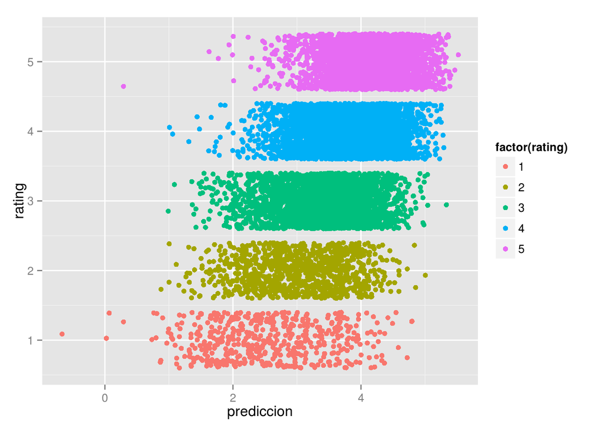

```r
ggplot(dat.valida.2, aes(x=prediccion, y=rating, colour=factor(rating))) + geom_jitter()
```

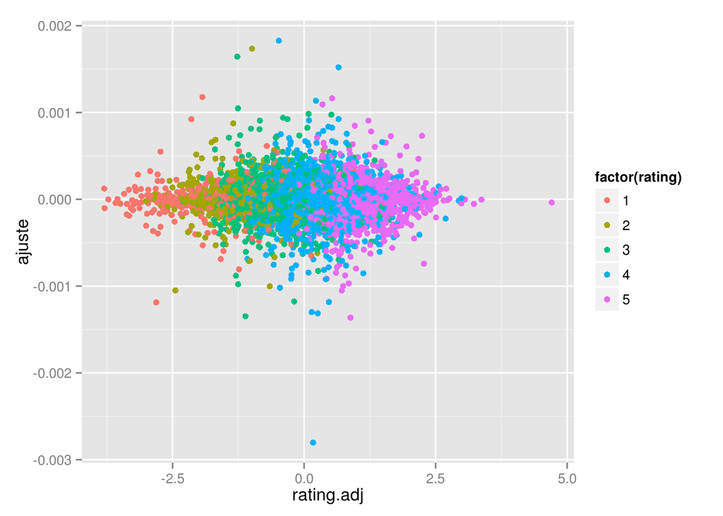

```r
# res=rating.adj
# calif=rating
# pred_base = prediccion

dat.valida.2$ajuste <- apply(dat.valida.2, 1, function(reng){
    Q[as.numeric(reng['user_id'])] * P[as.numeric(reng['movie_id_2'])]
    })
dat.valida.2$pred <- dat.valida.2$ajuste + dat.valida.2$prediccion

ggplot(dat.valida.2, aes(x=rating.adj, y=ajuste, colour=factor(rating))) + geom_point()
```